# Bernauer_Andrew_report3

Andrew Bernauer

February 12, 2019

# Difficult Learning Problems in Economics: Predicting Ether Price

# Report 1

## Introduction

For the semester long project I will be attempting to predict the known response variable ethereum price in terms of the predictors: block size, network hash rate growth rate, transactions, day of the week, and month. The project is regression based and not a classification task. Therefore the project will fall under the umbrella of supervised machine learning.

$$ether price = \beta_{o} + \beta_{1} \times blocksize + \beta_{2} \times networkhashgrowthrate + \beta_{3} \times transactions + \beta_{4} \times day + \beta_{5} \times month + \epsilon$$

Ethereum is a decentralized, open source, block chain technology, featuring smart contracts. The crypto currency that fuels the Ethereum block chain is Ether.

### Data

```r
library(scales)
library(ggplot2)
library(lubridate)
library(purrr)
library(dplyr)
library(readr)
library(tibble)
library(errorist)
library(broom)
library(caret)
library(tidyr)
#substitute in the path on your machine to files
ethereum_transaction_history <- read_csv("C:\\Users\\andre\\Documents\\ECON_490_ML\\ML_report 1\\ethereum-historical-data\\EthereumTransactionHistory.csv")
ethereum_block_size <-read_csv("C:\\Users\\andre\\Documents\\ECON_490_ML\\ML_report 1\\ethereum-historical-data\\EthereumBlockSizeHistory.csv"
)
ethereum_network_hash_rate <- read_csv("C:\\Users\\andre\\Documents\\ECON_490_ML\\ML_report 1\\ethereum-historical-data\\EthereumNetworkHashRateGrowthRate.csv")
ether_price <- read_csv("C:\\Users\\andre\\Documents\\ECON_490_ML\\ML_report 1\\ethereum-historical-data\\EtherPriceHistory(USD).csv")
# creating variable for day
day_of_week <-
  lubridate::mdy(ether_price$`Date(UTC)`) %>%
  wday( ,label=TRUE)  %>%
  sort()

# creating variable for month
month_of_year <-
  lubridate::mdy(ether_price$`Date(UTC)`) %>%
  month( ,label=TRUE) %>%
  sort()

signedlog10 <- function(x) {
  ifelse(abs(x) <= 1, 0, sign(x)*log10(abs(x)))
}

log_price <- signedlog10(ether_price[[3]])

log_history <- signedlog10(ethereum_transaction_history[[3]])

log_block_size <- signedlog10(ethereum_block_size[[3]])

log_hash_rate <- signedlog10(ethereum_network_hash_rate[[3]])

summary(log_price)
```

```
##    Min. 1st Qu.  Median    Mean 3rd Qu.    Max.
##  0.0000  0.9801  1.2708  1.5985  2.5227  3.1415
```

```r
summary(log_history)
```

```
##    Min. 1st Qu.  Median    Mean 3rd Qu.    Max.
##   0.000   4.570   4.803   4.967   5.732   6.130
```

```r
# construct list of variables to coerce into a tibble
l_ether <- list( price = ether_price[[3]],
                 transaction_history = as.integer(ethereum_transaction_history[[3]]),
                 block_size = as.integer(ethereum_block_size[[3]]),
                 hash_rate = ethereum_network_hash_rate[[3]],
                 day = day_of_week,
                 month = month_of_year,
                 date_utc = mdy(ethereum_network_hash_rate$`Date(UTC)`),
                 unix_time_stamp = ethereum_network_hash_rate$UnixTimeStamp,
                 log_10_price = log_price,
                 log_10_trans_history = log_history,
                 log_10_block_size = log_block_size,
                 log_10_hash_rate = log_hash_rate)

ether_df <- as_tibble(l_ether)


xs <-function(x){(x-mean(x))/(2*sd(x))}
```

#### Plots

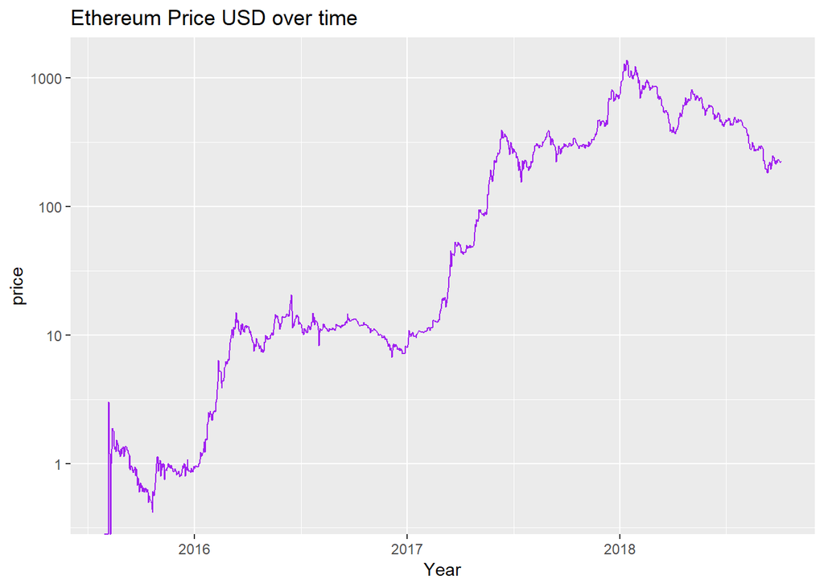

```r
price_history <- ggplot(ether_df) +
  aes(date_utc, price) +
  geom_line(color="purple") +
  xlab("Year")+
  ggtitle("Ethereum Price USD over time") +
  scale_y_log10()




 price_history
```

The price doesn’t seem move at all significantly until 2016 so I decided to use a log transformation to the y axis. This removed a large amount the visual noise and made the price change overtime more evident. Besides that ethereum price starts to rise from around a dollar price to hovering around the ten dollars between 2016 and 2017. Peaks at a value of 1000 dollars in 2018.

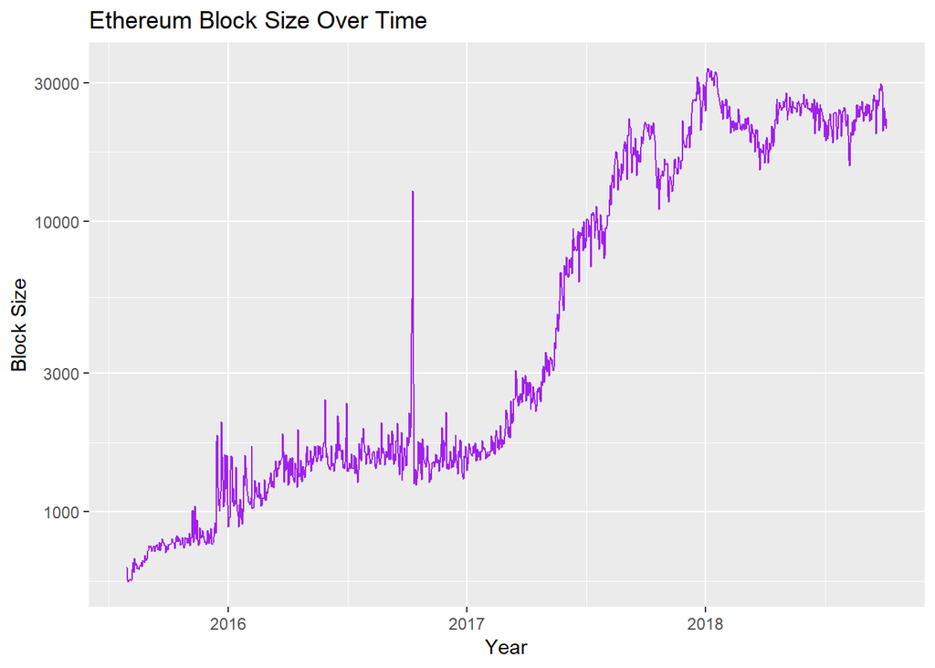

```r
block_history <- ggplot(ether_df) +
  aes(date_utc, block_size) +
  geom_line(color ="purple") +
  scale_y_log10() +
  xlab("Year") +
  ylab("Block Size") +
  ggtitle("Ethereum Block Size Over Time")


block_history
```

Block size rises exponentially begining in 2017. Prior to this it fluctuates up and down between 1000 and 3000 which might be pointing to autocorrelation. In this same time period it peaks violently at 10000. Reaching a maximum of over 30000 in 2018. Another log tranformation was used in this plot.

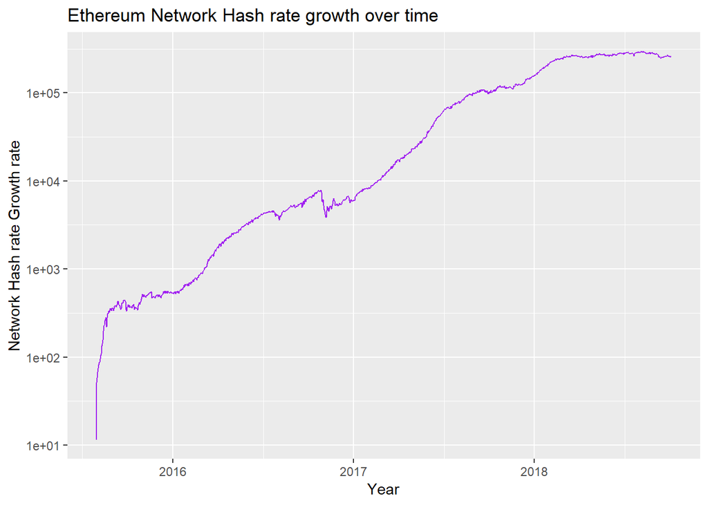

```r
 hashrate_history <- ggplot(ether_df) +
  aes(date_utc, hash_rate) +
  geom_line(color="purple") +
  scale_y_log10() +
  xlab("Year") +
  ylab("Network Hash rate Growth rate") +
  ggtitle("Ethereum Network Hash rate growth over time")

 hashrate_history
```

Network hashrate growth blows up exponentially and seems to follow that trend overtime.

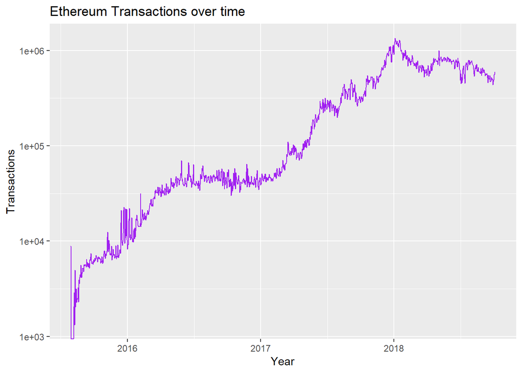

```r
 transaction_history <- ggplot(ether_df) +
  aes(date_utc, transaction_history) +
  geom_line(color="purple") +
  xlab("Year") +
  ylab("Transactions") +
  scale_y_log10() +
  ggtitle("Ethereum Transactions over time")

 transaction_history
```

Transactions on the the Ethereum network are growing significantly overtime and more people are embracing it’s use.

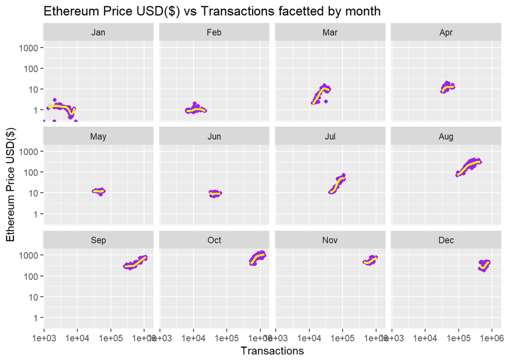

```r
 price_plot <- ggplot(ether_df) +
   aes(transaction_history, price) +
   geom_point(colour="purple") +
   facet_wrap(~month) +
   geom_smooth(colour="yellow", alpha = 0.25)

 price_plot +
   scale_x_log10("Transactions") +
   scale_y_log10("Ethereum Price USD($)") +
   ggtitle("Ethereum Price USD($) vs Transactions facetted by month")
```

There appears to be some clustering of Ether price as transactions increases on the block chain increase isolating by month.

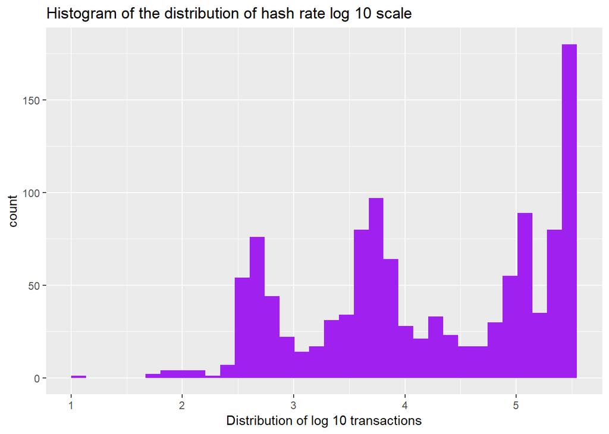

```r
p <- ggplot(ether_df) +
 aes(log_10_hash_rate) + geom_histogram(bins = 34, fill = "purple") +
  ggtitle(label = "Histogram of the distribution of hash rate log 10 scale") +
  xlab("Distribution of log 10 transactions")


p
```

Many of the $X_{1}, X_{2}, \dots, X_{n}$ or predictor variables in the dataset follow skewed distribution and feature multiple peaks. This could be pointing to the presence of sub-populations within the underlying data.

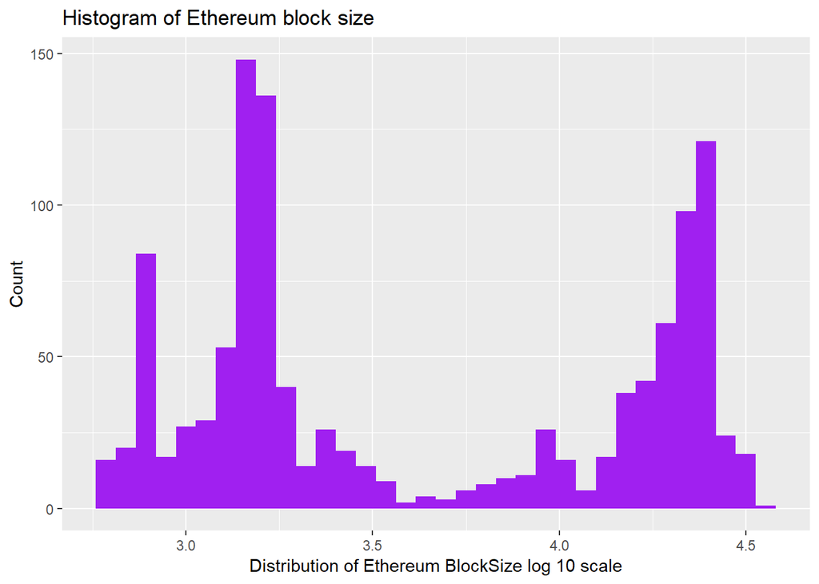

```r
ggplot(ether_df) +
  aes(log_block_size) + geom_histogram(bins = 34, fill = 'purple') +
  xlab("Distribution of Ethereum BlockSize log 10 scale") +
  ylab("Count") +
  ggtitle("Histogram of Ethereum block size")
```

Likewise, blocksize has this similar property this sort of distribution doesn’t suit itself well, for standard machine learning algorithms given the multiple peaks. Most of the variables follow gamma distributions in the cartesian coordinate scale. I declined to illustrate those graphs.

##### Summary Code

```r
#summary stats for ethereum price
ether_df %>% summarise(mean_price = mean(price, na.rm = TRUE), median_price = median(price), sd_price = sd(price), iqr_price = IQR(price), n = n(), mad_price = mad(price), min_price = min(price), max_price = max(price))
```

```
## # A tibble: 1 x 8
##   mean_price median_price sd_price iqr_price     n mad_price min_price
##        <dbl>        <dbl>    <dbl>     <dbl> <int>     <dbl>     <dbl>
## 1       212.         18.7     282.      324.  1164      26.9         0
## # ... with 1 more variable: max_price <dbl>
```

```r
#summary stats for ethereum transaction history
ether_df %>% summarise(mean_transaction_history = mean(transaction_history), median_transaction_history = median(transaction_history), sd_transaction_history = sd(transaction_history), iqr_transaction_history = IQR(transaction_history), n = n(), mad_transaction_history = mad(transaction_history), min_transaction_history = min(transaction_history), max_transaction_history = max(transaction_history))
```

```
## # A tibble: 1 x 8
##   mean_transactio~ median_transact~ sd_transaction_~ iqr_transaction~     n
##              <dbl>            <dbl>            <dbl>            <dbl> <int>
## 1          275451.           63518.          318759.          501880.  1164
## # ... with 3 more variables: mad_transaction_history <dbl>,
## #   min_transaction_history <dbl>, max_transaction_history <dbl>
```

```r
#summary stats for ethereum block size
ether_df %>% summarise(mean_block_size = mean(block_size), median_block_size = median(block_size), sd_block_size = sd(block_size), iqr_block_size = IQR(block_size), n = n(), mad_block_size = mad(block_size), min_block_size = min(block_size), max_block_size = max(block_size))
```

```
## # A tibble: 1 x 8
##   mean_block_size median_block_si~ sd_block_size iqr_block_size     n
##             <dbl>            <dbl>         <dbl>          <dbl> <int>
## 1           9292.             2209         9856.          18172  1164
## # ... with 3 more variables: mad_block_size <dbl>, min_block_size <dbl>,
## #   max_block_size <dbl>
```

```r
#summary stats for hash rate
ether_df %>% summarise(mean_hash_rate = mean(hash_rate), median_hash_rate = median(hash_rate), sd_hash_rate= sd(hash_rate), iqr_hash_rate = IQR(hash_rate), n = n(), mad_hash_rate = mad(hash_rate), min_hash_rate = min(hash_rate), max_hash_rate = max(hash_rate))
```

```
## # A tibble: 1 x 8
##   mean_hash_rate median_hash_rate sd_hash_rate iqr_hash_rate     n
##            <dbl>            <dbl>        <dbl>         <dbl> <int>
## 1         82768.           11610.      105868.       140979.  1164
## # ... with 3 more variables: mad_hash_rate <dbl>, min_hash_rate <dbl>,
## #   max_hash_rate <dbl>
```

# Report 2

## Regressions

```r
#running five regressions

poly_reg <- lm(price ~ poly(transaction_history, 5) + poly(block_size, 5) + poly(hash_rate, 5), ether_df )


reg_obj <- lm(log(price) ~ log(block_size) + log(transaction_history) + log(hash_rate), data = ether_df,  subset = price > 0)

reg_obj_2 <- lm(log(price) ~ log(transaction_history) + log(hash_rate), data = ether_df, subset = price > 0)


reg_obj_3 <- lm(price ~ I(block_size)^2 + sqrt(transaction_history) + hash_rate, data = ether_df)

mols <- lm(price ~ block_size + transaction_history + hash_rate, data = ether_df)

log_ols <- lm(log(price) ~ log(transaction_history), data = ether_df, subset = price > 0)
```

### Regression Diagnostics

```r
tidy_reg_obj <- reg_obj %>%
   tidy()

tidy_reg_obj
```

```
## # A tibble: 4 x 5
##   term                     estimate std.error statistic   p.value
##   <chr>                       <dbl>     <dbl>     <dbl>     <dbl>
## 1 (Intercept)              -10.6       0.211     -50.4  8.64e-294
## 2 log(block_size)            0.0720    0.0387      1.86 6.32e-  2
## 3 log(transaction_history)   1.01      0.0491     20.5  5.66e- 80
## 4 log(hash_rate)             0.222     0.0311      7.15 1.56e- 12
```

```r
glance_tidy_poly <- glance(poly_reg)

glance_reg_obj <- glance(reg_obj)

glance_reg_obj_2 <- glance(reg_obj_2)

glance_reg_obj_3 <- glance(reg_obj_3)

glance_mols <- glance(mols)

glance_log_ols <- glance(log_ols)


glance_tidy_poly$adj.r.squared
```

```
## [1] 0.9396409
```

```r
glance_reg_obj$adj.r.squared
```

```
## [1] 0.9638884
```

```r
glance_reg_obj_2$adj.r.squared
```

```
## [1] 0.9638114
```

```r
glance_reg_obj_3$adj.r.squared
```

```
## [1] 0.8428993
```

```r
glance_mols$adj.r.squared
```

```
## [1] 0.9012137
```

```r
glance_log_ols$adj.r.squared
```

```
## [1] 0.9620687
```

Predictors performing the best presented the following equation
$$\hat{y} = -10.65 + 0.072 \log(\text{Blocksize}) + 1.0007 \log(\text{TransactionHistory}) + 0.222\log(\text{Hashrate})$$
.

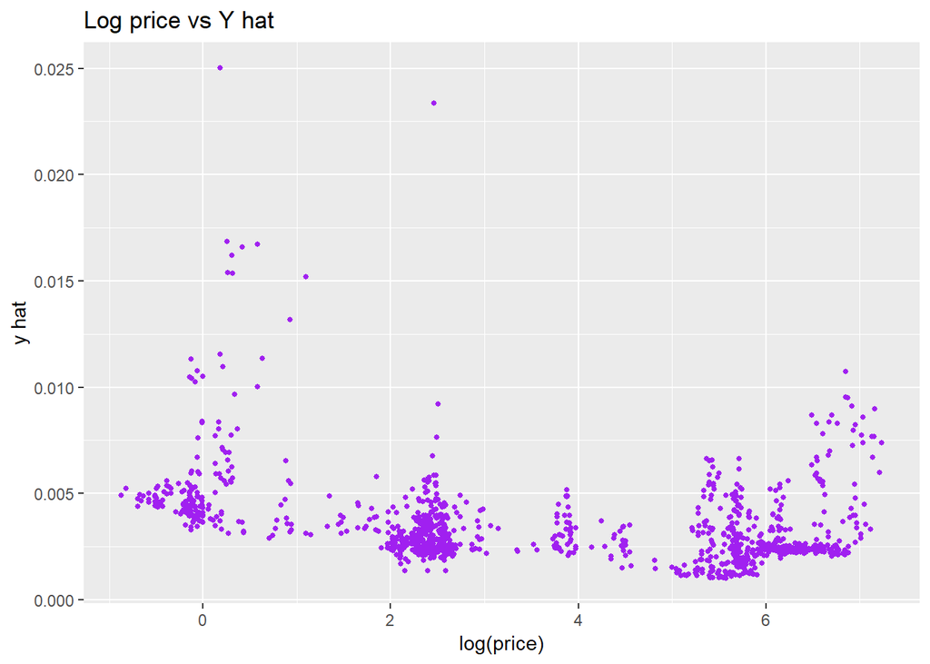

```r
augmented_reg_obj <- reg_obj %>%
             augment()

some_plot <- ggplot(data = augmented_reg_obj, aes(log.price., .hat)) +
  geom_point(color = "purple", size = 1) +
  labs(x="log(price)", y="y hat") +
  ggtitle("Log price vs Y hat")



some_plot
```

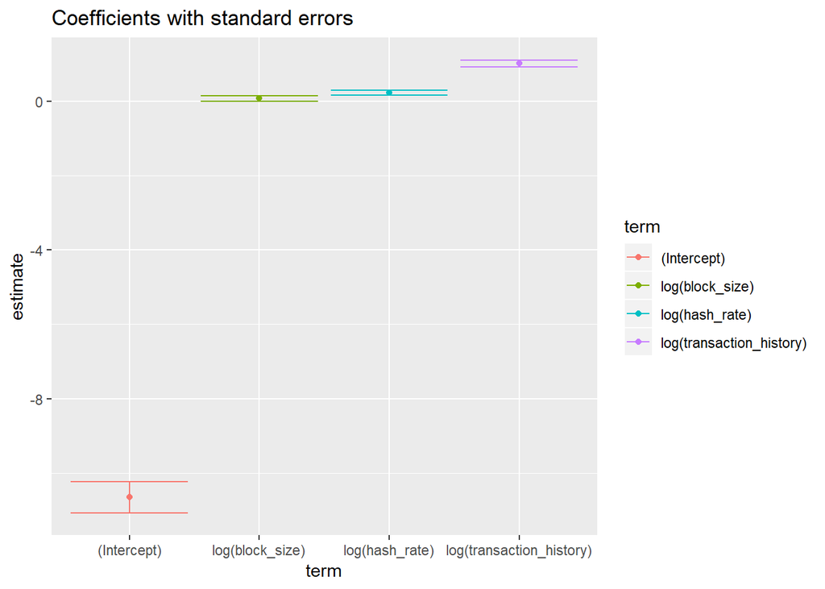

```r
tidy_conf_it <- tidy(reg_obj, conf.int = TRUE)

confint_plot <- ggplot(tidy_conf_it, aes(term, estimate, color=term)) +
  geom_point() +
  geom_errorbar(aes(ymin=estimate - 1.96*std.error, ymax=estimate + 1.96*std.error))


confint_plot +
  ggtitle("Coefficients with standard errors") +
  scale_x_discrete()
```

The previous graph is misleading due to the scale with a scale adjustment it is more insightful.

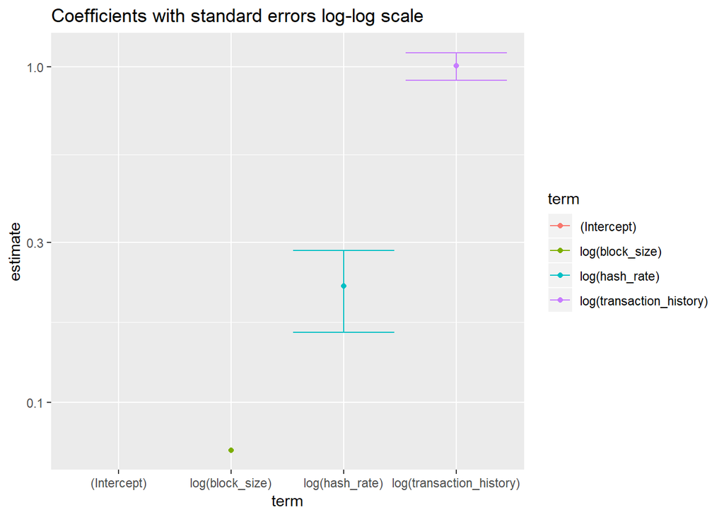

```r
confint_plot +
  scale_y_log10() +
  ggtitle("Coefficients with standard errors log-log scale") +
  scale_x_discrete()
```

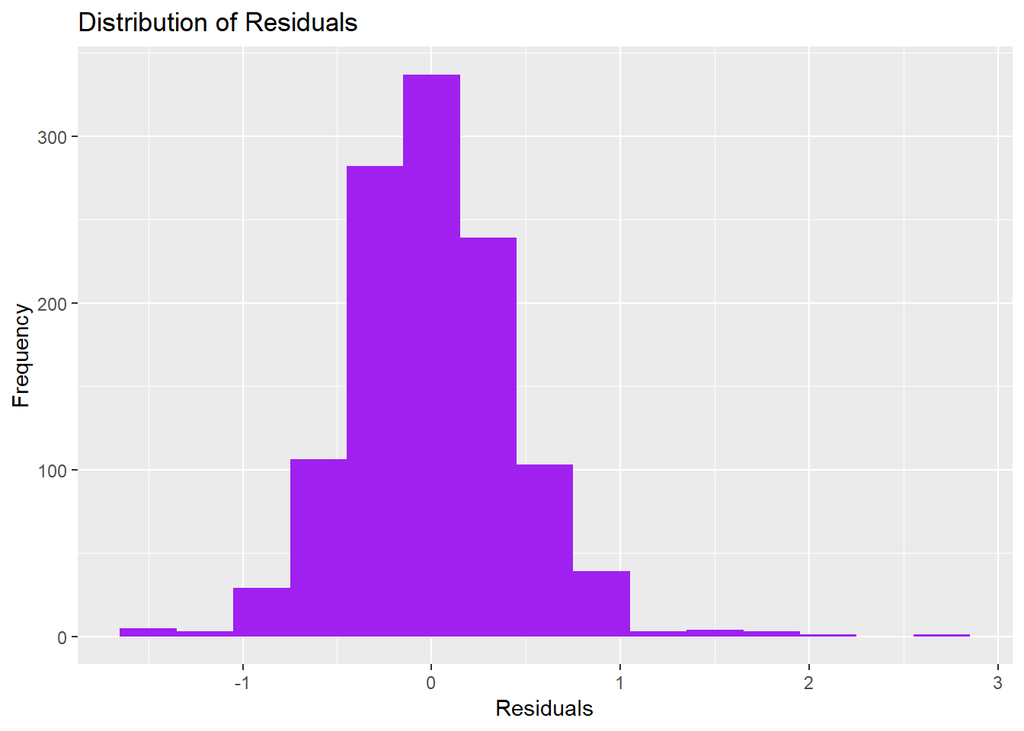

```r
some_plot_2 <- ggplot(data = augmented_reg_obj, aes(.resid)) +
  geom_histogram(binwidth = .3, fill = "purple") +
  labs(x="Residuals", y="Frequency") +
  ggtitle("Distribution of Residuals")



some_plot_2
```

The majority of the residuals are distributed between -1 and 1 peaking at zero. This distribution is similar to the laplace distribution.

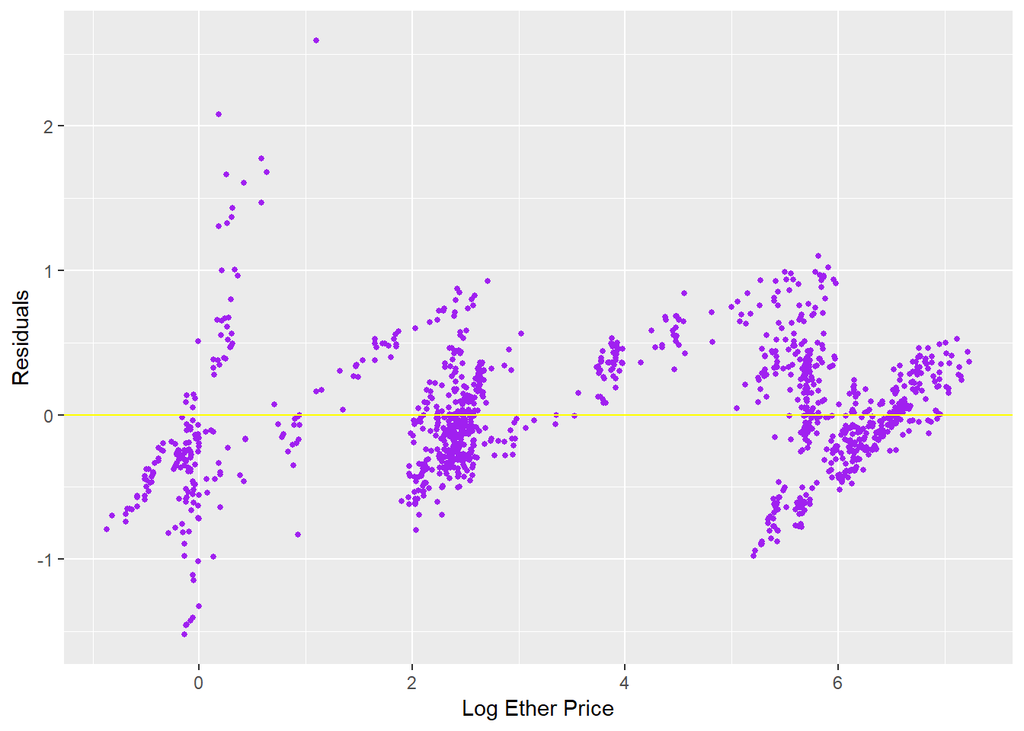

```r
some_plot_3 <- ggplot(augmented_reg_obj, aes(log.price., .resid)) +
  geom_point(color = "purple", size = 1) +
  geom_hline(color = "yellow", yintercept = 0)

some_plot_3 +
  labs(x="Log Ether Price", y="Residuals")
```

The Residuals plotted against Ether Price suggest there is possible non-normality in the distribution of the errors.

## KNN Regression

```r
library(caret)

set.seed(20)

train_index <- createDataPartition(ether_df$price, p = .8, list = FALSE, times = 1)

head(train_index)

ether_df_train <- ether_df[train_index, ]

ether_df_test <- ether_df[-train_index, ]

tr_control <- trainControl(method = "repeatedcv",
             number = 10,
             repeats = 3
             )
knn_model <-  train(price ~., data = ether_df,
                    method = "knn",
                    preProcess = c("center", "scale"),
                    trControl = tr_control,
                    metric = "RMSE",
                    tuneLength = 10
                    )

knn_model

knn_model$results

y_hat <- predict(knn_model, newdata = ether_df)

predicted <- predict(knn_model, ether_df)

plot(ether_df$price, predicted)
sqrt(sum((predicted - ether_df$price) ^ 2) / length(ether_df))
```

[output not shown]

# Report 3

## Ridge and Lasso Regressions

```r
library(glmnet)
```

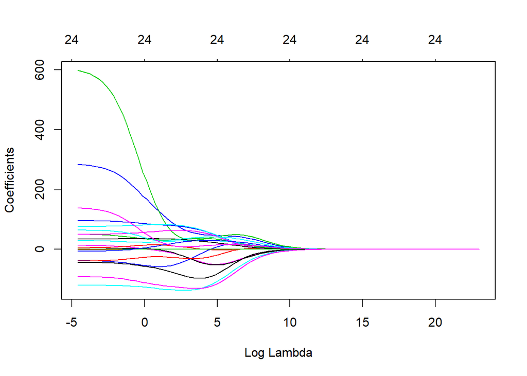

```r
library(caret)


set.seed(385)


train_df <- ether_df %>% sample_frac(0.5)
test_df <- ether_df %>% setdiff(train_df)

train_df <- train_df[, -9]

test_df <- test_df[, -9]

covariates_train <- model.matrix(price~. , data = train_df)[, c(-1, -9)]

covariates_test <- model.matrix(price~. , data=test_df)[, c(-1, -9)]
response_train <- as.numeric(unlist(train_df[1]))
response_test <- as.numeric((unlist(test_df[1])))

grid <- 10^seq(10, -2, length.out = 100)

ridge_model <- glmnet(covariates_train, response_train, alpha = 0, lambda = grid, family ="gaussian")

plot.glmnet(ridge_model, xvar = "lambda")
```

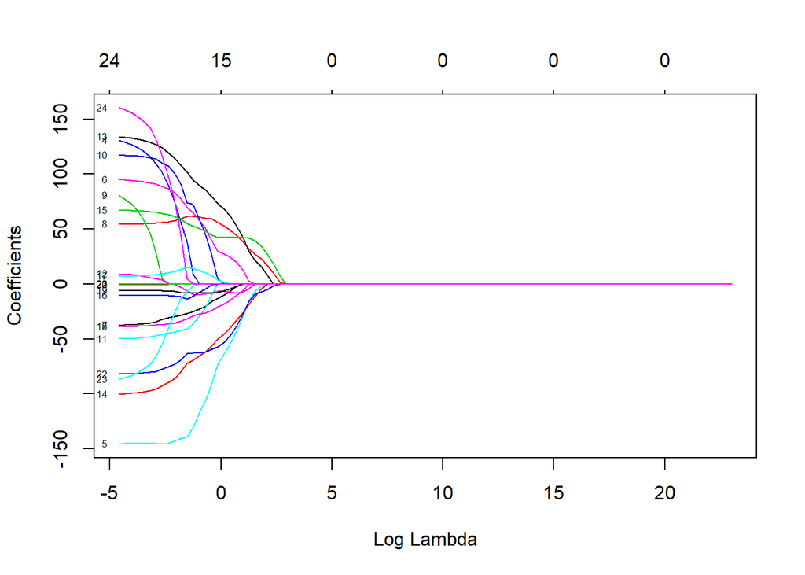

```r
lasso_model <- glmnet(covariates_test, response_train, alpha = 1, lambda = grid, family = "gaussian")


plot.glmnet(lasso_model, xvar = "lambda", label = "true")
```

Additionally, the lasso model has a $\lambda = 2.26$ which ends up culling eleven of the twenty five coefficients assocaited with the model matrix. Which is evident in the plot above.

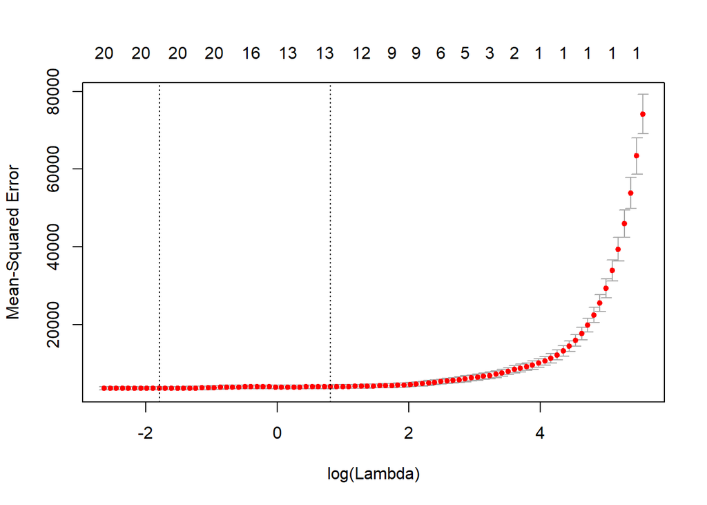

```r
set.seed(385)

cv_lasso <- cv.glmnet(covariates_train, train_df$price, alpha=1)


plot(cv_lasso)
```

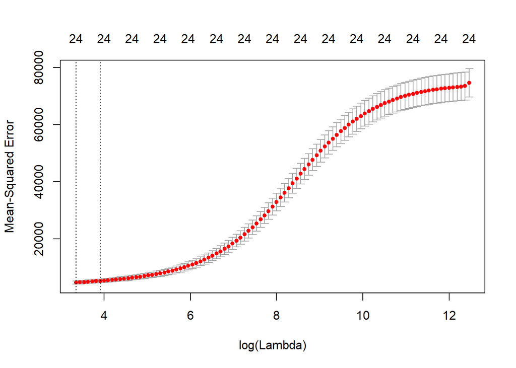

```r
set.seed(385)
cv_ridge <- cv.glmnet(covariates_train, train_df$price, alpha=0)

plot(cv_ridge)
```

```r
best_lambda_ridge <- cv_ridge$lambda.1se

best_lambda_lasso <- cv_lasso$lambda.1se

print(best_lambda_ridge)
```

```
## [1] 49.75677
```

```r
print(best_lambda_lasso)
```

```
## [1] 2.256409
```

I elect to pick a lambda within one standard deviation as a way to avoid overfitting the model to the training data and performing poorly on the test data.

```r
ridge_coefficients <- coef.glmnet(cv_ridge, newx = covariates_train,  s = best_lambda_ridge)



lasso_coef <- coef.glmnet(cv_lasso, newx = covariates_train, s = best_lambda_lasso)

print(lasso_coef)
```

```
## 25 x 1 sparse Matrix of class "dgCMatrix"
##                                  1
## (Intercept)          -3.865048e+00
## transaction_history   7.346843e-04
## block_size            9.728368e-04
## hash_rate             .
## day.L                 .
## day.Q                 .
## day.C                 .
## day^4                 .
## day^6                 1.125948e+01
## month.L               .
## month.Q              -4.776904e+01
## month.C              -1.264343e+02
## month^4              -1.060577e+02
## month^5              -4.023573e+01
## month^6              -2.353651e+00
## month^7               9.323836e+00
## month^8               4.602856e+01
## month^9               6.209852e+01
## month^10              5.560580e+01
## month^11              2.973271e+01
## date_utc              .
## unix_time_stamp       .
## log_10_trans_history  .
## log_10_block_size     .
## log_10_hash_rate      .
```

```r
print(ridge_coefficients)
```

```
## 25 x 1 sparse Matrix of class "dgCMatrix"
##                                  1
## (Intercept)          -4.590841e+02
## transaction_history   2.652731e-04
## block_size            4.839930e-03
## hash_rate             7.931908e-05
## day.L                 4.853365e+01
## day.Q                 2.936747e+01
## day.C                -4.298177e+01
## day^4                -4.509562e+01
## day^6                 1.057101e+00
## month.L               3.262475e+01
## month.Q              -1.250095e+01
## month.C              -1.302372e+02
## month^4              -1.303847e+02
## month^5              -9.759097e+01
## month^6              -3.011047e+01
## month^7               3.661883e+01
## month^8               6.355422e+01
## month^9               6.455279e+01
## month^10              5.658345e+01
## month^11              2.678415e+01
## date_utc              5.462198e-03
## unix_time_stamp       7.319991e-08
## log_10_trans_history  2.944909e+01
## log_10_block_size     4.098183e+01
## log_10_hash_rate      1.085118e+01
```

Lasso as an operator ending up culling the following coefficients: day.L, day.Q, day.C, day^4, Month.L, date_utc, unix_timestamp, and the other coefficients for transaction history, block size, hash rate in the log 10 scale. The model coefficients are not the most interpratable as they were produced via the model matrix

The same can be said for the ridge regression model.

```r
lasso_test_pred = predict.glmnet(lasso_model, newx = covariates_test, s=best_lambda_lasso)

ridge_test_pred = predict.glmnet(ridge_model, newx = covariates_test, s=best_lambda_ridge)

mean((response_test - lasso_test_pred) ^ 2)
```

```
## [1] 88166.71
```

```r
mean((response_test - ridge_test_pred) ^ 2)
```

```
## [1] 6682.426
```

The **Lasso** model returned an $MSE$ of 88166.71 while the **Ridge** model returned a more modest $MSE$ of 6682.426 on the test sets respectively. The Ridge regression model returns the lowest $MSE $of the two methods though the performance is not great.

## Regression trees

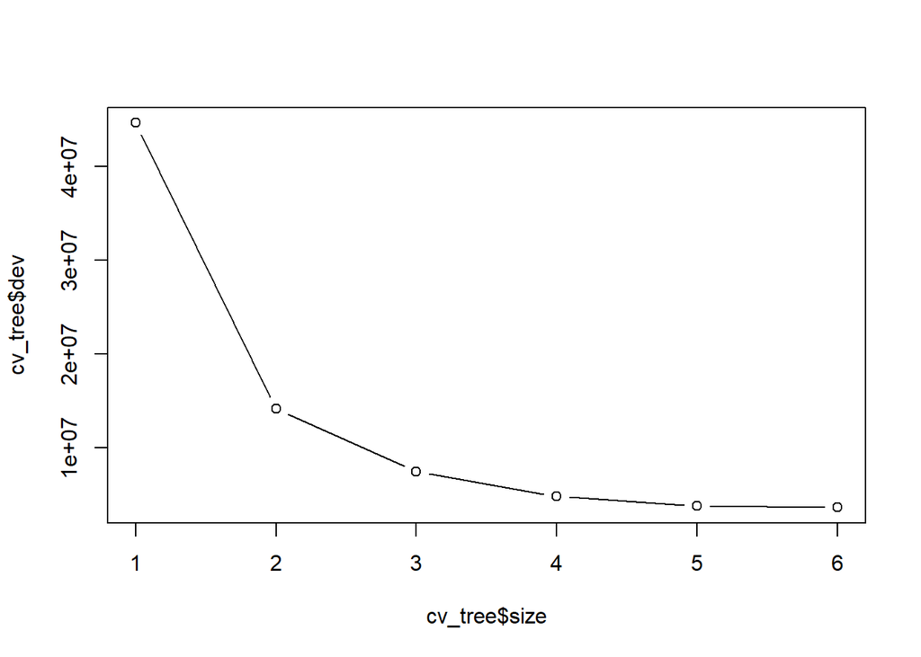

```r
library(tree)
set.seed(385)

ether_tree <- tree(price~., data = train_df)

cv_tree <- cv.tree(ether_tree, K=10 )
plot(cv_tree$size, cv_tree$dev, type = 'b')
```

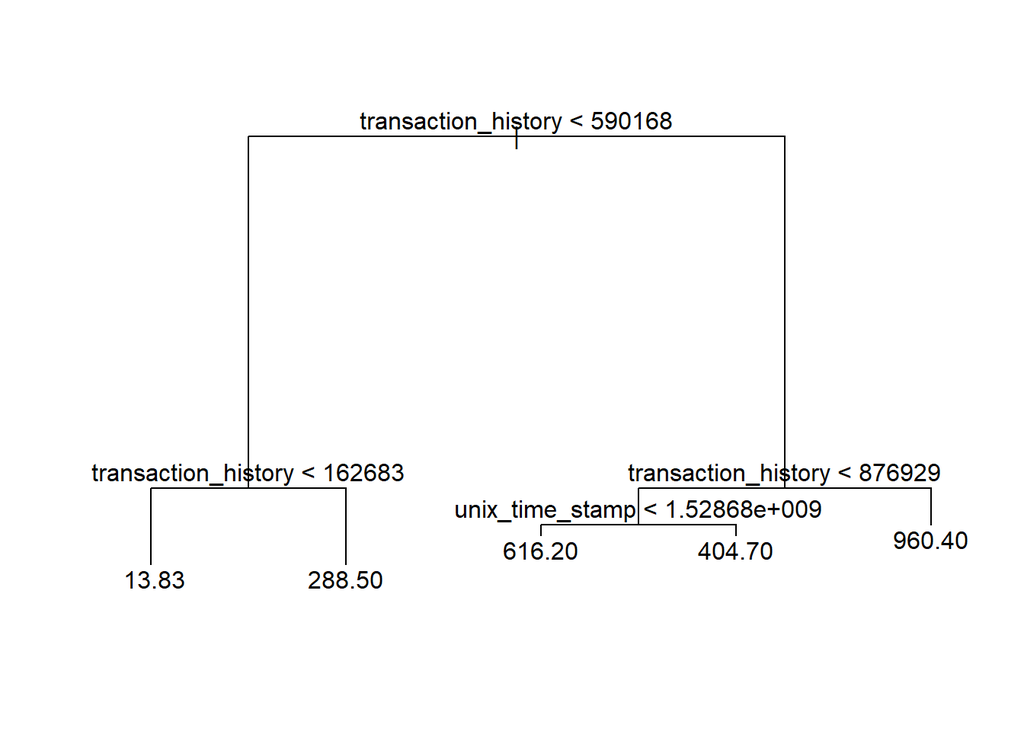

```r
pruned_tree_df <- prune.tree(ether_tree, best = 5)
plot(pruned_tree_df)
text(pruned_tree_df, pretty = 0)
```

```r
treee_fit = predict(pruned_tree_df, newdata = test_df)


single_tree_fit <- mean((response_test - treee_fit) ^ 2)

single_tree_fit
```

```
## [1] 8066.872
```

The pruned regression tree contains a total of five terminal nodes each displaying the average prediction based on those splits in the tree. The splits function to partition space into mutually exclusive regions.

## Bootstrapped trees

```r
set.seed(385)

statistic <- function(x, n=100, best=5){
  tree_1 <- tree(price~., data = train_df)
  pruned_tree_1 <- prune.tree(tree_1, k=10, best = best)

 return(  predict(pruned_tree_1, newdata = test_df) )



}

 result <- boot::boot(data = train_df, statistic, R=100, sim = "ordinary")

mean((test_df$price - result$t0) ^ 2)
```

```
## [1] 6845.105
```

The $MSE$ of the bootstrapped trees is a performance upgrade over the results from the previous performance of the single regression tree trained on the training data. This is not completely surprising as we would expect the model to perform better on our training data and to underperform on the test data. Surprisingly though I was able to get an $MSE$ that was significanctly better accross multiple seeds and fitting trees which is promising, for future reports. Of course there is a trade-off in that we don’t want our model to overfit the training data and not perform well on the test set.

### Conclusion

The performance of regression trees under multiple seeds proves to be a promising development as we start covering boosting, bagging, and random forests in further reports. Ridge was a decent improvement over a single tree aproach and performed roughly similar too . Additionally, the multimodal nature of some of the distribution could point to using a different performance metric than MSE possibly MAD mean absolute deviations, or MAE mean absolute errors.

## Bonus

```r
for (i in c(1:100)){

  set.seed(i)



  tree_t <- tree(price~., train_df)

  prune_tree_t <- prune.tree(tree_t, best = 5)




  single_tree_est <- predict(prune_tree_t, newdata = test_df)


 z <- (mean( single_tree_est - test_df$price) ^ 2)

}




z
```

```
## [1] 119.217
```